# General introduction to the hdp package

Nicola Roberts

April 2018

# Contents

Model categorical count data with a Hierarchical Dirichlet Process as described by Teh et al. (Hierarchical Dirichlet Processes, Journal of the American Statistical Association, 2006, 101:476). This R package was adapted from [open source MATLAB and C code](http://www.stats.ox.ac.uk/~teh/research/npbayes/npbayes-r21.tgz) written by Yee Whye Teh.

```r
library(hdp)
```

# 1 Terminology and method overview

The input data consists of counts of **data items** in each data **category** for each **sample**. The HDP model assumes the data is drawn from a mixture of underlying categorical distributions that are shared (in different mixture ratios) across samples.

The user defines a tree-like structure for the HDP, wherein each DP **node** draws a mixture of categorical data distributions from its parent node. Data is assigned to particular DP nodes (usually one sample per leaf node), and the structure of the parent DP nodes defines hierarchies of sample-relatedness given some prior knowledge of sample groups.

In each iteration of the posterior sampling process, every data item is assigned to a raw **cluster**. After posterior sampling, raw clusters are grouped into **components**. Unlike the raw clusters, the components won’t be “too small” (a raw cluster could contain just one data item) nor “too similar” (the distribution of categories in two raw clusters could be about the same, but these raw clusters would then be grouped into one component), and there will be the same number of components across all posterior samples (the number of raw clusters varies across posterior samples). After grouping the raw clusters into global components, any data item that is not assigned to a main component is assigned to **component zero**. This “zero” component contains the proportion of the dataset with uncertain clustering behaviour, possibly due to noise.

# 2 Toy dataset

To illustrate the basic features of the *hdp* package, we consider a toy dataset of categorical count data with **10 samples** (rows) and **6 categories** (columns). The counts were simulated from two underlying categorical distributions with a different average mixture ratio in the first and last set of five samples.

```r
example_data_hdp
```

```
##       [,1] [,2] [,3] [,4] [,5] [,6]
##  [1,]   12   12   16   32   22    9
##  [2,]   11   13   18   60   18    9
##  [3,]   11   17   32   74   31   16
##  [4,]  134   83  143  346  145   87
##  [5,]   15    3    8   17    7    2
##  [6,]   64   18   21   35   19   25
##  [7,]   46   25   28   39   21   31
##  [8,]   41   19   22   35   21   23
##  [9,]   30    5    7    7    8    9
## [10,]   93   15   23   19   16   42
```

# 3 Quick start with basic HDP structure

## 3.1 Initialise hdpState object via hdp_quick_init

Use `hdp_quick_init()` to initialise a basic default HDP structure with one top parent DP node with no associated data, and one child DP node per sample. Every DP node shares the same concentration parameter, and will automatically be ‘activated’ (made available for posterior sampling). The base distribution is a uniform Dirichlet with psuedocount 1 in each data category.

```r
set.seed(10)
quick_hdp <- hdp_quick_init(example_data_hdp)
quick_hdp
```

```
## Object of class hdpState
##  Number of DP nodes: 11
##  Index of parent DP: 0 1 1 1 1 1 1 1 1 1 ...
##  Number of data items per DP: 0 103 129 181 938 52 182 190 161 66 ...
##  Index of conparam per DP: 1 1 1 1 1 1 1 1 1 1 ...
##  Conparam hyperparameters and current value:
##            Shape Rate Value
## Conparam 1     1    1     1
##  Number of data categories: 6
##  Number of clusters: 2
##  Initialised with 2 clusters, using random seed 5074783
```

`hdp_quick_init()` returns a `hdpState` object. Notice that it has 11 DP nodes (one parent, and one for each of 10 samples), and that the index of the parent node is 0 for the first DP (the parent is the top node) and 1 for the others. The first DP node (the parent) has no associated data items, while the second DP node has 103 (first sample), the third has 129 (second sample) and so on. With the default settings, the number of initial clusters is 2, and the hyperparameters for the concentration parameter are both 1.

Note that initialising clusters is random, and so the seed is reported for reproducibility. *However*, `hdp_quick_init()` does not let the user set a seed, so for reproducible results the seed can be set before running `hdp_quick_init()` *or* the HDP can be defined manually (see below) and the seed set via `dp_activate()`.

## 3.2 Run posterior sampling chain

The output of `hdp_quick_init()` is ready for posterior sampling via `hdp_posterior()`. The user must specify the number of burn-in iterations, the number of posterior samples to collect, and the number of iterations between each collected sample. Each iteration re-assigns the cluster allocation of every data item, given the current allocations of all other data items.

```r
quick_chain <- hdp_posterior(quick_hdp, burnin=500, n=100, space=40, seed=1234)
```

```
## [1] "500 burn-in iterations in 0.0 mins"
```

```r
quick_chain
```

```
## Object of class hdpSampleChain
##  Random seed: 1234
##  Burn-in iters: 500
##  Posterior samples: 100
##  Iters b/w samples: 40
##  Tabulate raw cluster number across samples:
##  2  3  4  5  6  7  8  9 10
## 15 27 31 16  5  2  2  1  1
##  Components: NO. Run hdp_extract_components
##  ----------
##  Final hdpState:
## Object of class hdpState
##  Number of DP nodes: 11
##  Index of parent DP: 0 1 1 1 1 1 1 1 1 1 ...
##  Number of data items per DP: 0 103 129 181 938 52 182 190 161 66 ...
##  Index of conparam per DP: 1 1 1 1 1 1 1 1 1 1 ...
##  Conparam hyperparameters and current value:
##            Shape Rate     Value
## Conparam 1     1    1 0.8915059
##  Number of data categories: 6
##  Number of clusters: 4
##  Initialised with 2 clusters, using random seed 5074783
```

`hdp_posterior()` returns a `hdpSampleChain` object. Notice that the number of raw clusters varies across the 100 posterior samples collected off the chain.

## 3.3 Assess quality of posterior sampling chain

Theoretically, an infinitely long posterior sampling chain would sample all possible cluster models in proportion to their likelihood. In practice, we aim to have a finite posterior sample set that approximates the true infinite random sampling space.

To assess the choice of burn-in time and number of iterations between collected samples, consider the following set of diagnostic plots (ideally, want no strong trends across posterior samples).

Note that the best approximation of the infinite random sampling space is achieved with multiple independent sampling chains (described in a later section).

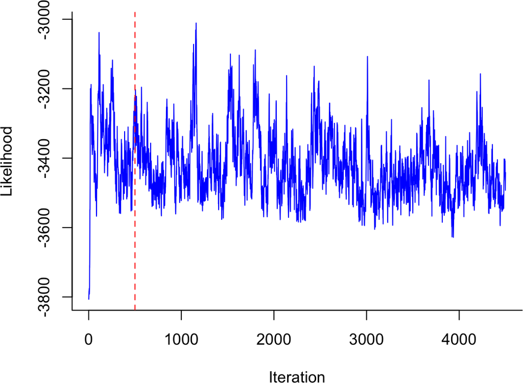

```r
plot_lik(quick_chain, bty="L")
```

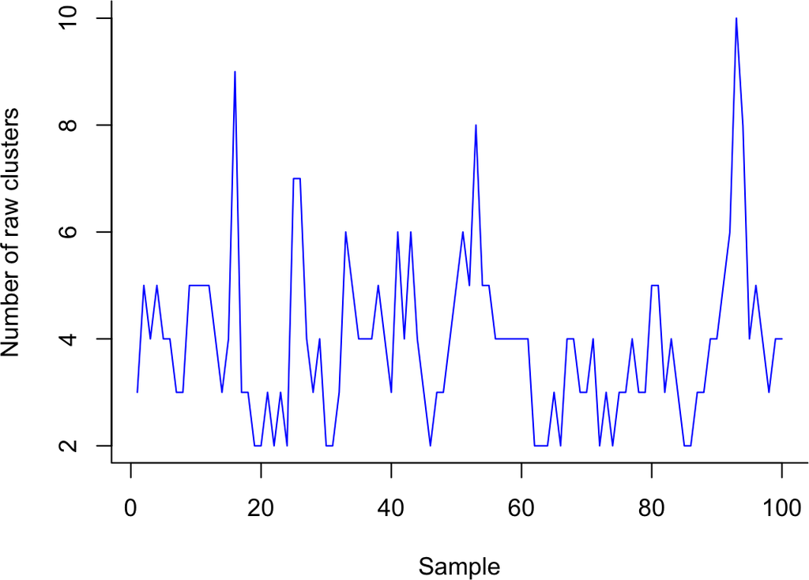

```r
plot_numcluster(quick_chain, bty="L")
```

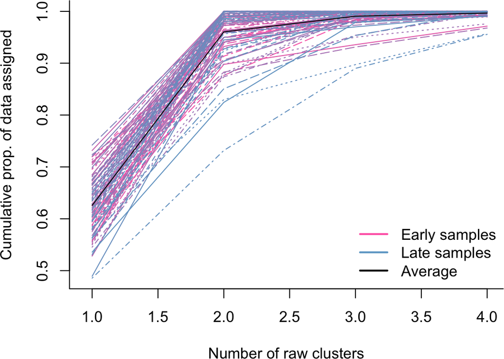

```r
plot_data_assigned(quick_chain, bty="L")
```

If the burn-in time was too short, the function `cull_posterior_samples()` throws away the first `ncull` posterior samples collected, effectively extending the burn-in time post-hoc.

## 3.4 Extract components from hdpSampleChain

The raw cluster assignments are not a particularly useful description of the dataset because the number of raw clusters varies across posterior samples, and some raw clusters may be very small (e.g. one data item in its own cluster), or have very similar distributions across data categories (effectively describing one underlying process twice).

To provide a more useful summary of the posterior samples, the raw clusters are consolidated into components (constant number across posterior samples).

For a `hdpSampleChain` object, the `hdp_extract_components()` function matches up the clusters across posterior samples and groups them into components such that:

- clusters are merged if their cosine similarity is above `cos.merge` (default 0.90), and
- clusters are assigned to component zero if they have no significant data categories or sample exposure.

```r
quick_chain <- hdp_extract_components(quick_chain)
quick_chain
```

```
## Object of class hdpSampleChain
##  Random seed: 1234
##  Burn-in iters: 500
##  Posterior samples: 100
##  Iters b/w samples: 40
##  Tabulate raw cluster number across samples:
##  2  3  4  5  6  7  8  9 10
## 15 27 31 16  5  2  2  1  1
##  Components: YES. Prop of data explained = 0.96  Merged if cosine sim > 0.9
##  Component number: 2
##  ----------
##  Final hdpState:
## Object of class hdpState
##  Number of DP nodes: 11
##  Index of parent DP: 0 1 1 1 1 1 1 1 1 1 ...
##  Number of data items per DP: 0 103 129 181 938 52 182 190 161 66 ...
##  Index of conparam per DP: 1 1 1 1 1 1 1 1 1 1 ...
##  Conparam hyperparameters and current value:
##            Shape Rate     Value
## Conparam 1     1    1 0.8915059
##  Number of data categories: 6
##  Number of clusters: 4
##  Initialised with 2 clusters, using random seed 5074783
```

Note that `quick_chain` now includes component information, using two components to explain 96% of the data.

The following plot shows the number of data items assigned to each component in each posterior sample.

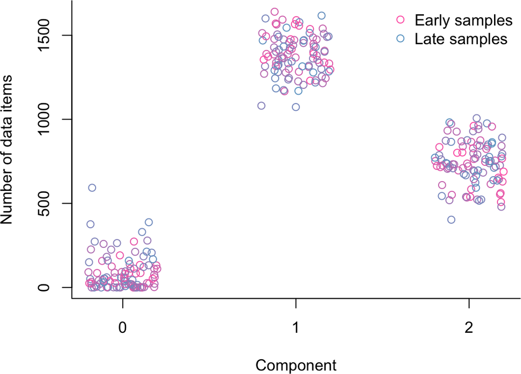

```r
plot_comp_size(quick_chain, bty="L", lab=c(3, 5, 7))
```

The following plot shows the mean distribution of data categories for each component, and the 95% credibility intervals (thin black lines). See `?plot_comp_distn` for more options.

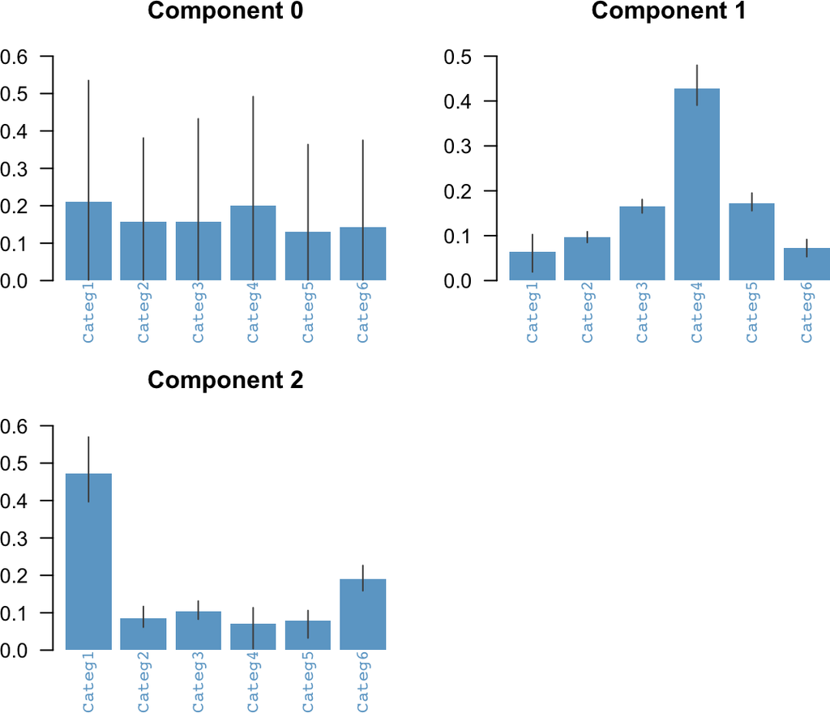

```r
par(mfrow=c(2,2), mar=c(3, 3, 2, 1))
plot_comp_distn(quick_chain, cat_names=paste0("Categ", 1:6), col="skyblue3")
```

The following plots show the mean distribution of components at each specified DP node. See `?plot_dp_comp_exposure` for more options.

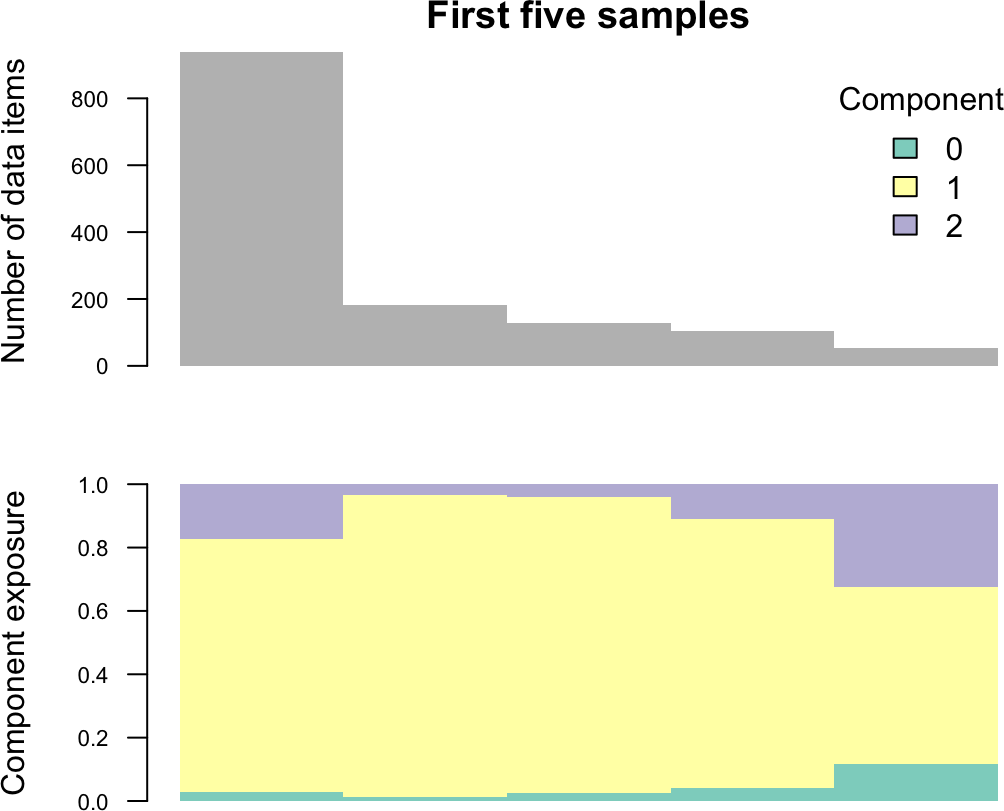

```r
plot_dp_comp_exposure(quick_chain, dpindices=2:6, main_text="First five samples",
                      col=RColorBrewer::brewer.pal(4, "Set3"))
```

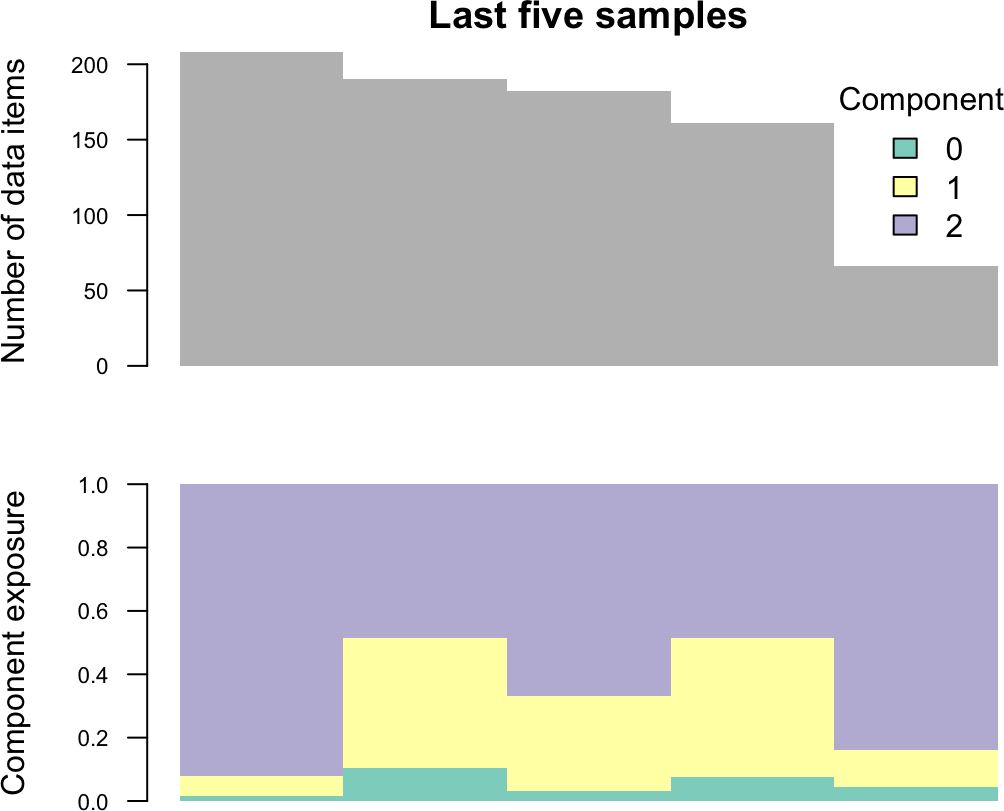

```r
plot_dp_comp_exposure(quick_chain, dpindices=7:11, main_text="Last five samples",
                      col=RColorBrewer::brewer.pal(4, "Set3"))
```

Note that posterior samples collected off just one finite chain are somewhat correlated with each other, and the variance of the output statistics will tend to be underestimated. This problem is redressed in the next example by using multiple independent sampling chains.

# 4 Customised HDP structure

## 4.1 Initialise hdpState object via hdp_init and friends

Use `hdp_init()` to initialise a custom HDP structure by specifying a number of starting nodes, their parent relationships, the parameters (pseudocounts) of the base distribution, and a set of hyperparameters for the gamma priors over one or more concentration parameters.

```r
my_hdp <- hdp_init(ppindex=c(0, 1, 1),
                   cpindex=c(1, 2, 2),
                   hh=rep(1, 6),
                   alphaa=rep(2, 2),
                   alphab=rep(0.5, 2))
my_hdp
```

```
## Object of class hdpState
##  Number of DP nodes: 3
##  Index of parent DP: 0 1 1 ...
##  Number of data items per DP: 0 0 0 ...
##  Index of conparam per DP: 1 2 2 ...
##  Conparam hyperparameters and current value:
##            Shape Rate Value
## Conparam 1     2  0.5     4
## Conparam 2     2  0.5     4
##  Number of data categories: 6
##  Number of clusters: 0
```

Further DP nodes can be added to the structure via `hdp_adddp()`, and further concentration parameters can be added via `hdp_addconparam()`.

Next, we add two more concentration parameters, and ten further DP nodes (five children per parent).

```r
my_hdp <- hdp_addconparam(my_hdp,
                          alphaa=rep(2, 2),
                          alphab=rep(0.5, 2))
my_hdp <- hdp_adddp(my_hdp,
                    numdp=10,
                    ppindex=rep(2:3, each=5),
                    cpindex=rep(3:4, each=5))
my_hdp
```

```
## Object of class hdpState
##  Number of DP nodes: 13
##  Index of parent DP: 0 1 1 2 2 2 2 2 3 3 ...
##  Number of data items per DP: 0 0 0 0 0 0 0 0 0 0 ...
##  Index of conparam per DP: 1 2 2 3 3 3 3 3 4 4 ...
##  Conparam hyperparameters and current value:
##            Shape Rate Value
## Conparam 1     2  0.5     4
## Conparam 2     2  0.5     4
## Conparam 3     2  0.5     4
## Conparam 4     2  0.5     4
##  Number of data categories: 6
##  Number of clusters: 0
```

Data is assigned via `hdp_setdata()`, with one row of data assigned to each of the DP nodes specified.

```r
my_hdp <- hdp_setdata(my_hdp,
                      dpindex=4:13,
                      data=example_data_hdp)
my_hdp
```

```
## Object of class hdpState
##  Number of DP nodes: 13
##  Index of parent DP: 0 1 1 2 2 2 2 2 3 3 ...
##  Number of data items per DP: 0 0 0 103 129 181 938 52 182 190 ...
##  Index of conparam per DP: 1 2 2 3 3 3 3 3 4 4 ...
##  Conparam hyperparameters and current value:
##            Shape Rate Value
## Conparam 1     2  0.5     4
## Conparam 2     2  0.5     4
## Conparam 3     2  0.5     4
## Conparam 4     2  0.5     4
##  Number of data categories: 6
##  Number of clusters: 0
```

## 4.2 Run multiple posterior sampling chains

When initialised, the DP nodes are ‘heldout’ (not available for posterior sampling). Use `dp_activate()` to activate them and specify the number of starting clusters. To see the effect:

```r
dp_activate(my_hdp, dpindex=1:13, initcc=2, seed=5678)
```

```
## Object of class hdpState
##  Number of DP nodes: 13
##  Index of parent DP: 0 1 1 2 2 2 2 2 3 3 ...
##  Number of data items per DP: 0 0 0 103 129 181 938 52 182 190 ...
##  Index of conparam per DP: 1 2 2 3 3 3 3 3 4 4 ...
##  Conparam hyperparameters and current value:
##            Shape Rate Value
## Conparam 1     2  0.5     4
## Conparam 2     2  0.5     4
## Conparam 3     2  0.5     4
## Conparam 4     2  0.5     4
##  Number of data categories: 6
##  Number of clusters: 2
##  Initialised with 2 clusters, using random seed 5678
```

After `dp_activate`, the `hdpState` object will be ready for posterior sampling!

In this example, I run four independent posterior sampling chains, with different `dp_activate` seeds to start the clustering from a different random starting point each time. At the end, use `hdp_multi_chain()` to store the results together in a `hdpSampleMulti` object. This approach is recommended, because the variance of the solution is likely to be underestimated if only one posterior sampling chain is used.

```r
chlist <- vector("list", 4)

for (i in 1:4){

  activated_hdp <- dp_activate(my_hdp, dpindex=1:13, initcc=2, seed=i*1e2)

  chlist[[i]] <- hdp_posterior(activated_hdp,
                               burnin=2500,
                               n=50,
                               space=100,
                               cpiter=2,
                               seed=i*1e4)
}
```

```
## [1] "2500 burn-in iterations in 0.0 mins"
## [1] "2500 burn-in iterations in 0.0 mins"
## [1] "2500 burn-in iterations in 0.0 mins"
## [1] "2500 burn-in iterations in 0.0 mins"
```

```r
chlist[1:2]
```

```
## [[1]]
## Object of class hdpSampleChain
##  Random seed: 10000
##  Burn-in iters: 2500
##  Posterior samples: 50
##  Iters b/w samples: 100
##  Tabulate raw cluster number across samples:
##  2  3  4  5  6  7  8
## 14 10 16  6  1  2  1
##  Components: NO. Run hdp_extract_components
##  ----------
##  Final hdpState:
## Object of class hdpState
##  Number of DP nodes: 13
##  Index of parent DP: 0 1 1 2 2 2 2 2 3 3 ...
##  Number of data items per DP: 0 0 0 103 129 181 938 52 182 190 ...
##  Index of conparam per DP: 1 2 2 3 3 3 3 3 4 4 ...
##  Conparam hyperparameters and current value:
##            Shape Rate     Value
## Conparam 1     2  0.5  1.125048
## Conparam 2     2  0.5  5.925581
## Conparam 3     2  0.5 14.206076
## Conparam 4     2  0.5  4.890458
##  Number of data categories: 6
##  Number of clusters: 4
##  Initialised with 2 clusters, using random seed 100
##
## [[2]]
## Object of class hdpSampleChain
##  Random seed: 20000
##  Burn-in iters: 2500
##  Posterior samples: 50
##  Iters b/w samples: 100
##  Tabulate raw cluster number across samples:
##  2  3  4  5  6  7
## 12 10 15  5  6  2
##  Components: NO. Run hdp_extract_components
##  ----------
##  Final hdpState:
## Object of class hdpState
##  Number of DP nodes: 13
##  Index of parent DP: 0 1 1 2 2 2 2 2 3 3 ...
##  Number of data items per DP: 0 0 0 103 129 181 938 52 182 190 ...
##  Index of conparam per DP: 1 2 2 3 3 3 3 3 4 4 ...
##  Conparam hyperparameters and current value:
##            Shape Rate     Value
## Conparam 1     2  0.5 1.1167672
## Conparam 2     2  0.5 0.5392442
## Conparam 3     2  0.5 2.6698407
## Conparam 4     2  0.5 2.9780919
##  Number of data categories: 6
##  Number of clusters: 2
##  Initialised with 2 clusters, using random seed 200
```

```r
multi <- hdp_multi_chain(chlist)
multi
```

```
## Object of class hdpSampleMulti
##  Number of chains: 4
##  Total posterior samples: 200
##  Components: NO. Run hdp_extract_components
##  ----------
##  Final hdpState from first chain:
## Object of class hdpState
##  Number of DP nodes: 13
##  Index of parent DP: 0 1 1 2 2 2 2 2 3 3 ...
##  Number of data items per DP: 0 0 0 103 129 181 938 52 182 190 ...
##  Index of conparam per DP: 1 2 2 3 3 3 3 3 4 4 ...
##  Conparam hyperparameters and current value:
##            Shape Rate     Value
## Conparam 1     2  0.5  1.125048
## Conparam 2     2  0.5  5.925581
## Conparam 3     2  0.5 14.206076
## Conparam 4     2  0.5  4.890458
##  Number of data categories: 6
##  Number of clusters: 4
##  Initialised with 2 clusters, using random seed 100
```

The constituent chains stored in a `hdpSampleMulti` object can be accessed via `chains()`.

## 4.3 Diagnostic plots for hdpSampleMulti

To plot diagnostics for the constituent chains stored within a `hdpSampleMulti` object, use `lapply()` over `chains()`.

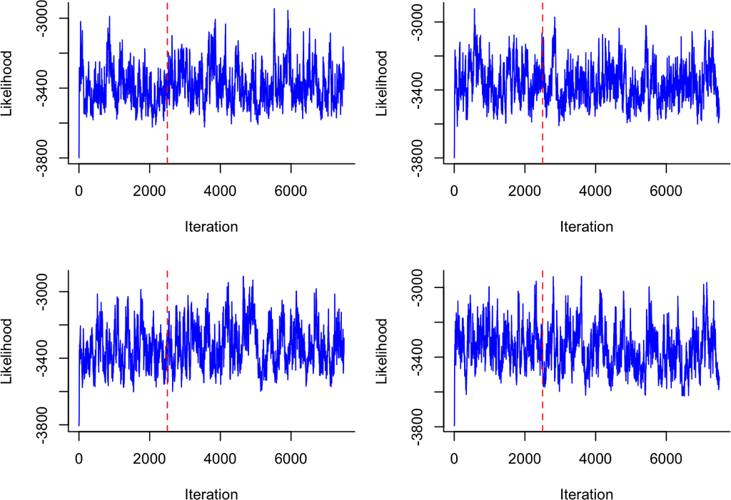

```r
par(mfrow=c(2,2), mar=c(4, 4, 2, 1))
p1 <- lapply(chains(multi), plot_lik, bty="L")
```

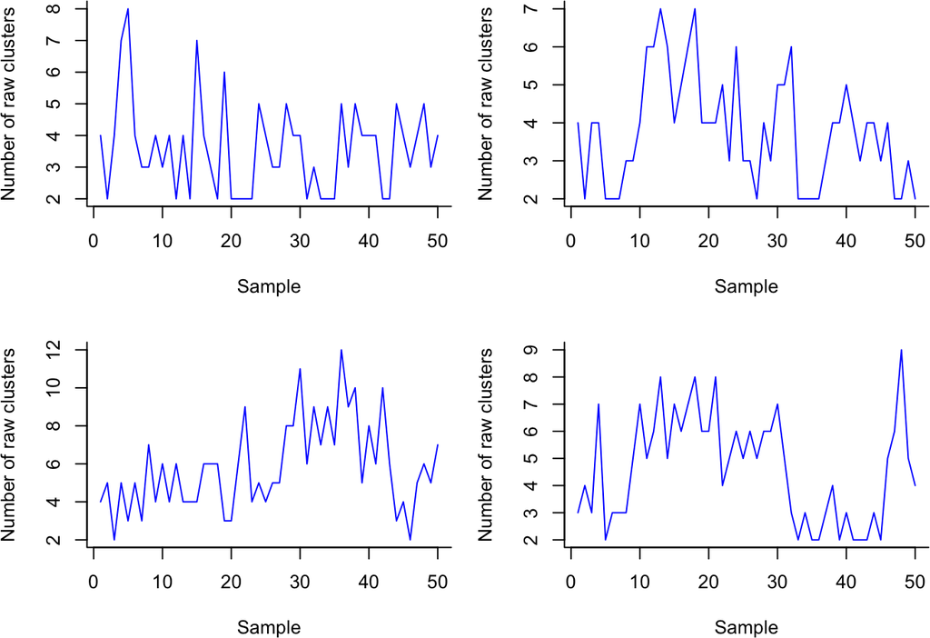

```r
p2 <- lapply(chains(multi), plot_numcluster, bty="L")
```

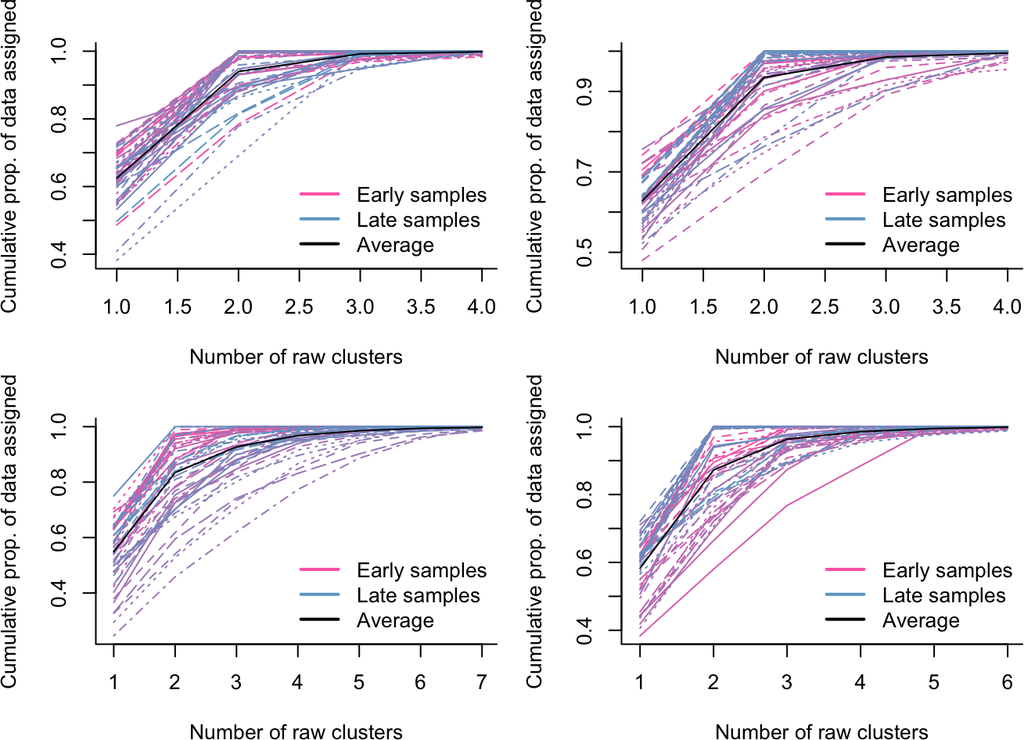

```r
p3 <- lapply(chains(multi), plot_data_assigned, bty="L")
```

## 4.4 Extract components from hdpSampleMulti

For a `hdpSampleMulti` object, the `hdp_extract_components()` function matches clusters across posterior samples (considering all chains together), and groups them into components. Recall that data items not assigned to the main components are captured by the ‘zero component’ for noise and uncertainty.

```r
multi <- hdp_extract_components(multi)
multi
```

```
## Object of class hdpSampleMulti
##  Number of chains: 4
##  Total posterior samples: 200
##  Components: YES. Prop of data explained = 0.892  Merged if cosine sim > 0.9
##  Component number: 2
##  ----------
##  Final hdpState from first chain:
## Object of class hdpState
##  Number of DP nodes: 13
##  Index of parent DP: 0 1 1 2 2 2 2 2 3 3 ...
##  Number of data items per DP: 0 0 0 103 129 181 938 52 182 190 ...
##  Index of conparam per DP: 1 2 2 3 3 3 3 3 4 4 ...
##  Conparam hyperparameters and current value:
##            Shape Rate     Value
## Conparam 1     2  0.5  1.125048
## Conparam 2     2  0.5  5.925581
## Conparam 3     2  0.5 14.206076
## Conparam 4     2  0.5  4.890458
##  Number of data categories: 6
##  Number of clusters: 4
##  Initialised with 2 clusters, using random seed 100
```

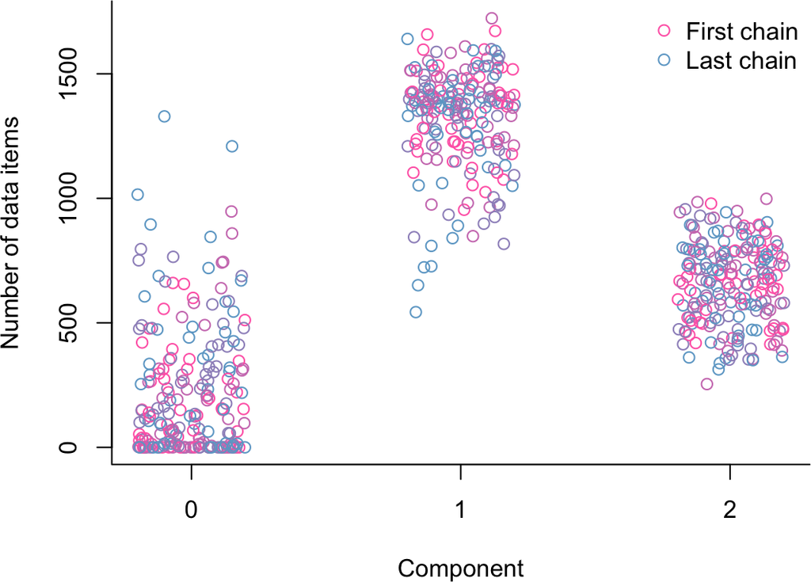

```r
plot_comp_size(multi, bty="L", lab=c(3, 5, 7))
```

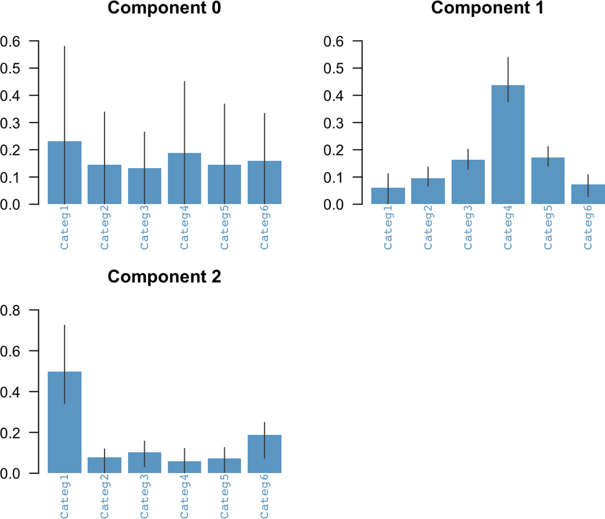

```r
par(mfrow=c(2,2), mar=c(3, 3, 2, 1))
plot_comp_distn(multi, cat_names=paste0("Categ", 1:6), col="skyblue3")

par(mfrow=c(1,1))
```

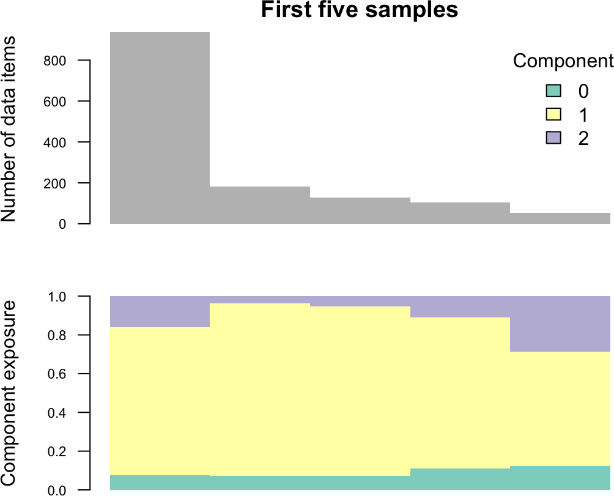

```r
plot_dp_comp_exposure(multi, dpindices=4:8, main_text="First five samples",
                      col=RColorBrewer::brewer.pal(3, "Set3"))
```

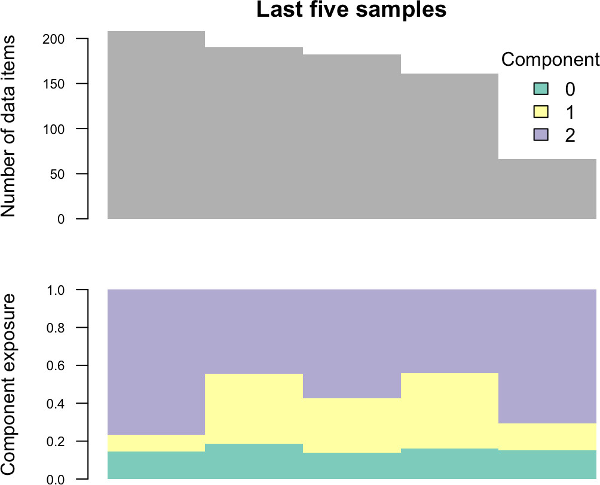

```r
plot_dp_comp_exposure(multi, dpindices=9:13, main_text="Last five samples",
                      col=RColorBrewer::brewer.pal(3, "Set3"))
```

# 5 Conditioning on prior knowledge

To condition on prior knowledge about possible components (underlying catagorical data distributions), use `hdp_prior_init` to initialise a `hdpState` object with one top parent DP node (active) with no associated data, and one child DP node (frozen) per prior component. The frozen nodes signifying prior components contain some number of pseudo-data items - use these pseudocounts to specify the relative weighting of each prior component compared to the volume of observed data. HDP can *simultaneously* match data to known priors *and* discover any new or unspecified components.

In the following example, a toy dataset of 100 samples and 10 data categories was simulated from four underlying components.

```r
# the dataset has 100 rows (samples) and 10 columns (data categories):
dim(example_data_hdp_prior)
```

```
## [1] 100  10
```

```r
# the two provided known priors:
example_known_priors
```

```
##             [,1]       [,2]
##  [1,] 0.09523810 0.06666667
##  [2,] 0.14285714 0.06666667
##  [3,] 0.04761905 0.16666667
##  [4,] 0.19047619 0.10000000
##  [5,] 0.02380952 0.11666667
##  [6,] 0.19047619 0.03333333
##  [7,] 0.14285714 0.10000000
##  [8,] 0.07142857 0.13333333
##  [9,] 0.02380952 0.08333333
## [10,] 0.07142857 0.13333333
```

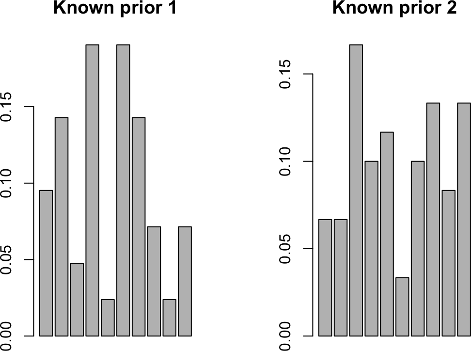

```r
par(mfrow=c(1,2))
barplot(example_known_priors[,1], main='Known prior 1')
barplot(example_known_priors[,2], main='Known prior 2')
```

Two of these underlying components are provided and input as prior information with a pseudocount weighting of 1000 data items each.

Prior components are preserved by `hdp_extract_components` and are prefixed with “P”. Any new components identified are prefixed with “N”.

```r
# a bit slow to run (few minutes) - load pre-made copy
# hdp_p <- hdp_prior_init(example_known_priors, rep(1000, 2), hh=rep(1, 10),
#              alphaa=c(1,1), alphab=c(1,1))
# hdp_p <- hdp_addconparam(hdp_p, alphaa=c(1,1), alphab=c(1,1))
# hdp_p <- hdp_adddp(hdp_p, 101, c(1, rep(4, 100)), c(3, rep(4, 100)))
# hdp_p <- hdp_setdata(hdp_p, 5:104, example_data_hdp_prior)
#
# chlist <- vector("list", 4)
#
# for (i in 1:4){
#
#   activated_hdp <- dp_activate(hdp_p, dpindex=4:104, initcc=4, seed=i*1e3)
#
#   chlist[[i]] <- hdp_posterior(activated_hdp,
#                                burnin=2500,
#                                n=50,
#                                space=100,
#                                cpiter=2,
#                                seed=i*1e5)
# }
#
# hdp_p <- hdp_multi_chain(chlist)

# loading pre-made copy
hdp_p
```

```
## Object of class hdpSampleMulti
##  Number of chains: 4
##  Total posterior samples: 200
##  Components: NO. Run hdp_extract_components
##  ----------
##  Final hdpState from first chain:
## Object of class hdpState
##  Number of DP nodes: 104
##  Number of pseudo DP nodes for prior info: 2
##  Index of pseudo DP nodes: 2 3 ...
##  Index of parent DP: 0 1 1 1 4 4 4 4 4 4 ...
##  Number of data items per DP: 0 999 1000 0 1043 86 9 55 904 92 ...
##  Index of conparam per DP: 1 2 2 3 4 4 4 4 4 4 ...
##  Conparam hyperparameters and current value:
##            Shape Rate     Value
## Conparam 1     1    1 1.0210541
## Conparam 2     1    1 0.9219566
## Conparam 3     1    1 2.4292968
## Conparam 4     1    1 3.0981053
##  Number of data categories: 10
##  Number of clusters: 4
##  Initialised with 4 clusters, using random seed 1000
```

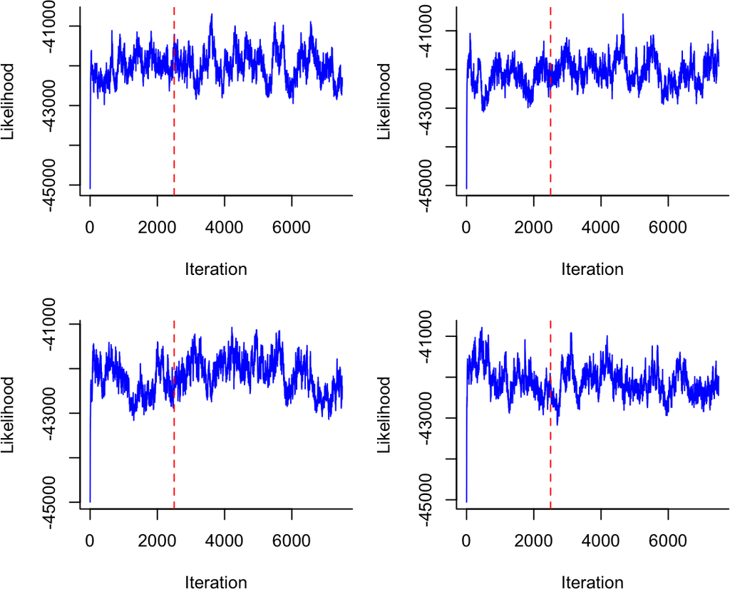

```r
par(mfrow=c(2,2), mar=c(4, 4, 2, 1))
p1 <- lapply(chains(hdp_p), plot_lik, bty="L")
```

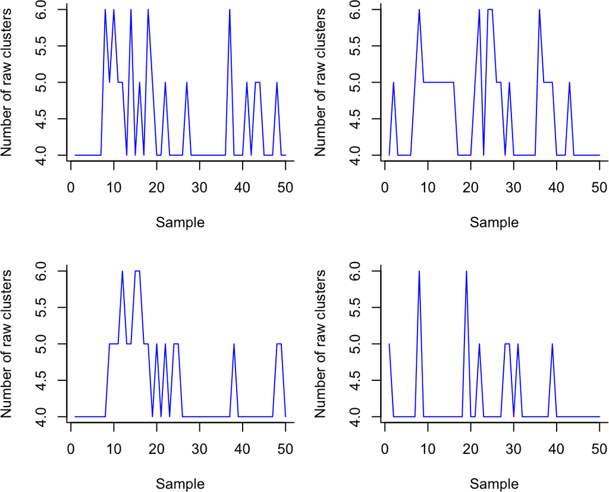

```r
p2 <- lapply(chains(hdp_p), plot_numcluster, bty="L")
```

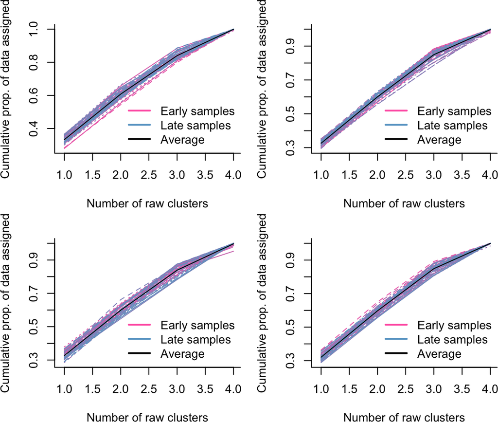

```r
p3 <- lapply(chains(hdp_p), plot_data_assigned, bty="L")
```

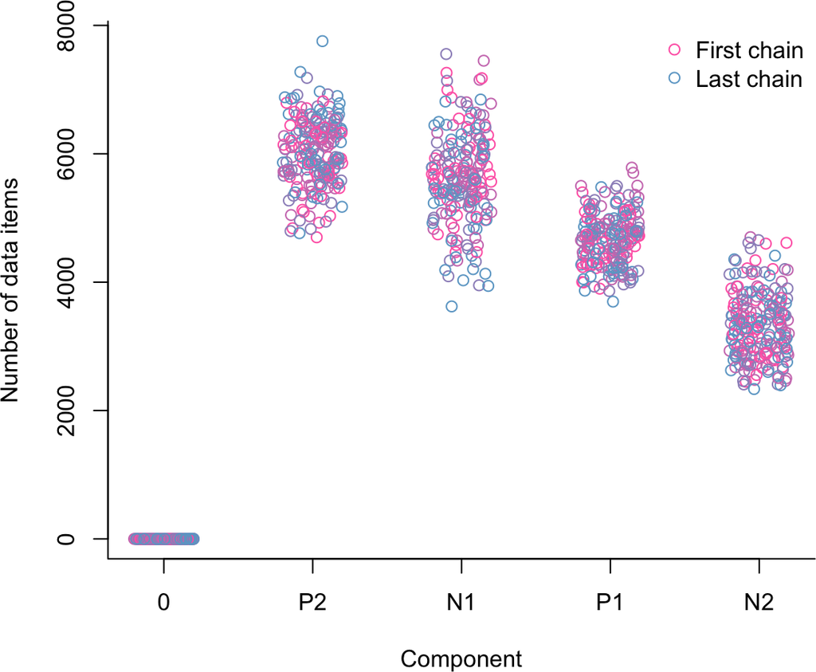

```r
hdp_p <- hdp_extract_components(hdp_p)
par(mfrow=c(1,1))
plot_comp_size(hdp_p, bty="L")
```

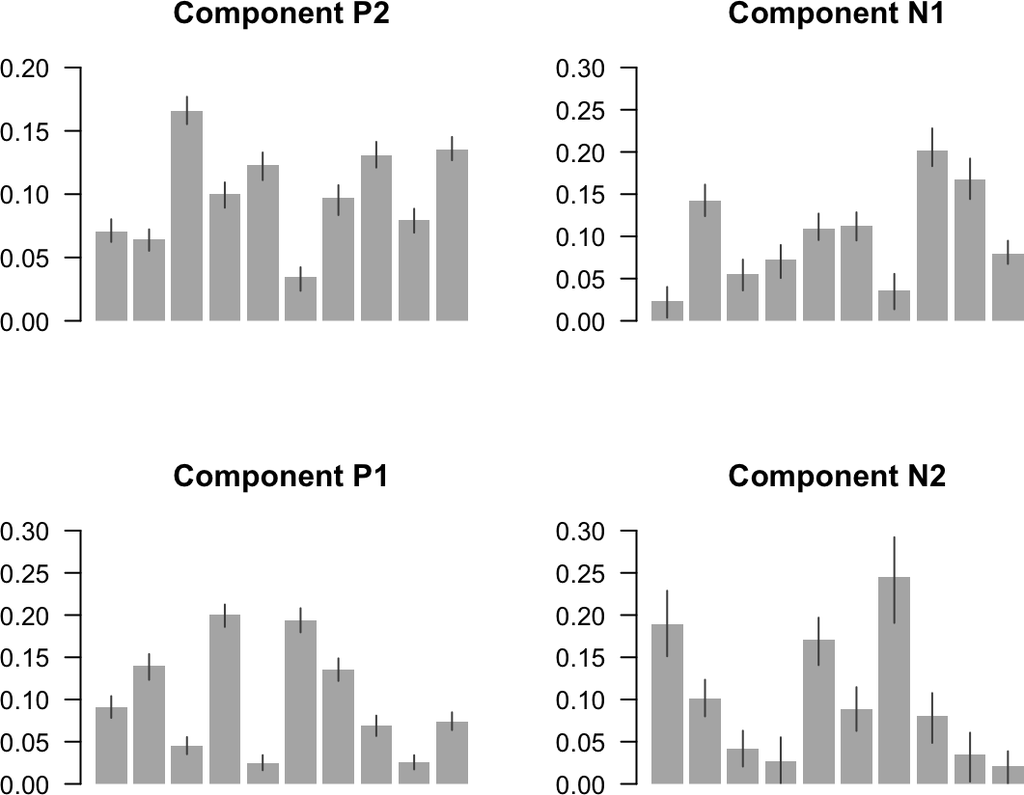

```r
par(mfrow=c(2,2))
plot_comp_distn(hdp_p, comp=1:4)
```

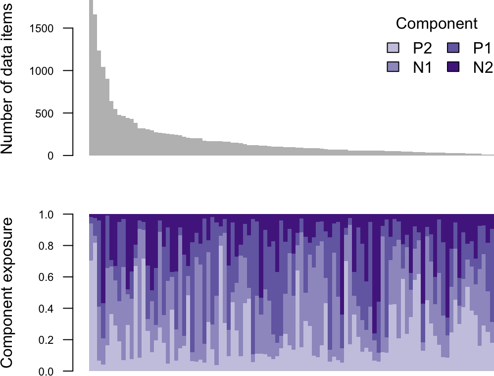

```r
par(mfrow=c(1,1))
plot_dp_comp_exposure(hdp_p, 5:104, col_comp=RColorBrewer::brewer.pal(5, 'Purples'))
```

# 6 Access internal details of hdp object classes

For documentation on `hdpState` objects, see `class?hdpState`. Some slots of `hdpState` can be accessed like so:

```r
# number of data categories
numcateg(quick_hdp)
```

```
## [1] 6
```

```r
# number of DP nodes
numdp(quick_hdp)
```

```
## [1] 11
```

```r
# number of concentration parameters
numconparam(quick_hdp)
```

```
## [1] 1
```

```r
# 'base' distribution above the top DP node
base(quick_hdp)
```

```
## Object of class hdpBase
##  Number of data categories: 6
##  Prior over data categories: 1 1 1 1 1 ...
##  Number of raw clusters: 2
```

```r
# parameters of 'base' distribution above top DP node
base_params(quick_hdp)
```

```
## [1] 1 1 1 1 1 1
```

```r
# concentration parameter details
conparam(quick_hdp)
```

```
## [[1]]
## Object of class hdpConparam
##  Parameters of gamma prior: 1 1
##  Value: 1
##  Number of DPs using this concentration param: 11
```

```r
# DP node detail
dp(quick_hdp)[1:5]
```

```
## [[1]]
## Object of class hdpDP
##  Number of data items: 0
##  Number of child data tables in each cluster: 26 28 0
##
## [[2]]
## Object of class hdpDP
##  Number of data items: 103
##  Number of data items in each cluster: 49 54 0
##  Number of data items in each category: 12 12 16 32 22 9
##
## [[3]]
## Object of class hdpDP
##  Number of data items: 129
##  Number of data items in each cluster: 64 65 0
##  Number of data items in each category: 11 13 18 60 18 9
##
## [[4]]
## Object of class hdpDP
##  Number of data items: 181
##  Number of data items in each cluster: 82 99 0
##  Number of data items in each category: 11 17 32 74 31 16
##
## [[5]]
## Object of class hdpDP
##  Number of data items: 938
##  Number of data items in each cluster: 452 486 0
##  Number of data items in each category: 134 83 143 346 145 87
```

```r
# DP 'state' for each node
# 2 is activated (included in posterior sampling)
# 1 is frozen (conditioned on during posterior sampling)
# 0 is heldout (ignored during postering sampling)
dpstate(quick_hdp)
```

```
##  [1] 2 2 2 2 2 2 2 2 2 2 2
```

```r
# index of parent node for each node
ppindex(quick_hdp)
```

```
##  [1] 0 1 1 1 1 1 1 1 1 1 1
```

```r
# index of concentration parameter for each node
cpindex(quick_hdp)
```

```
##  [1] 1 1 1 1 1 1 1 1 1 1 1
```

```r
# seed used when activating nodes (initialising cluster assignments)
activating_seed(quick_hdp)
```

```
## [1] 5074783
```

```r
# index of frozen nodes containing psuedo-data for prior components,
# only used if initialised via hdp_prior_init
# pseudoDP()
```

For documentation on `hdpSampleChain` objects, see `class?hdpSampleChain`. Some slots of `hdpSampleChain` can be accessed like so:

```r
# random seed
sampling_seed(quick_chain)
```

```
## [1] 1234
```

```r
# settings of the posterior sampling chain
hdp_settings(quick_chain)
```

```
## $burnin
## [1] 500
##
## $n
## [1] 100
##
## $space
## [1] 40
##
## $cpiter
## [1] 1
```

```r
# instance of the hdpState object at the end of the chain
final_hdpState(quick_chain)
```

```
## Object of class hdpState
##  Number of DP nodes: 11
##  Index of parent DP: 0 1 1 1 1 1 1 1 1 1 ...
##  Number of data items per DP: 0 103 129 181 938 52 182 190 161 66 ...
##  Index of conparam per DP: 1 1 1 1 1 1 1 1 1 1 ...
##  Conparam hyperparameters and current value:
##            Shape Rate     Value
## Conparam 1     1    1 0.8915059
##  Number of data categories: 6
##  Number of clusters: 4
##  Initialised with 2 clusters, using random seed 5074783
```

```r
# data likelihood (given model) after every iteration
lik(quick_chain)[1:10]
```

```
##  [1] -3806.550 -3797.611 -3785.083 -3781.256 -3785.502 -3775.924 -3791.719
##  [8] -3783.203 -3768.355 -3709.135
```

```r
# number of raw clusters in each posterior sample
numcluster(quick_chain)[1:10]
```

```
##  [1] 3 5 4 5 4 4 3 3 5 5
```

```r
# concentration parameter values at each posterior sample
cp_values(quick_chain)[1:10]
```

```
##  [1] 1.6164217 1.4151818 0.5592224 0.8389532 0.8782383 0.7114196 1.5594301
##  [8] 0.5435943 1.8672598 1.4803740
```

```r
# List of matrices (one from each posterior sample) counting the category-cluster
# data assignment across all DP nodes. Number of rows is the number of
# categories (constant), and number of columns is the number of clusters
# in that posterior sample (variable).
clust_categ_counts(quick_chain)[1:3]
```

```
## [[1]]
##      [,1] [,2] [,3] [,4]
## [1,]   40  406   11    0
## [2,]  121   89    0    0
## [3,]  213  102    3    0
## [4,]  566   97    1    0
## [5,]  218   88    2    0
## [6,]   72  179    2    0
##
## [[2]]
##      [,1] [,2] [,3] [,4] [,5] [,6]
## [1,]  151  289    3   14    0    0
## [2,]  158   36    1   15    0    0
## [3,]  250   44    0   22    2    0
## [4,]  630    2    3   29    0    0
## [5,]  274   22    2    7    3    0
## [6,]  127  115    0   11    0    0
##
## [[3]]
##      [,1] [,2] [,3] [,4] [,5]
## [1,]  109  298    0   50    0
## [2,]  151   35    0   24    0
## [3,]  251   50    0   17    0
## [4,]  634   23    2    5    0
## [5,]  276   29    0    3    0
## [6,]  116  104    0   33    0
```

```r
# List of matrices (one from each posterior sample) counting within-DP cluster
# assignment (aggregating across data categories). Number of rows is the number of
# DPs (constant), and number of columns is the number of clusters in that posterior sample (variable).
clust_dp_counts(quick_chain)[1:3]
```

```
## [[1]]
## 11 x 4 sparse Matrix of class "dgCMatrix"
##
##  [1,]  42  26  3 .
##  [2,]  76  27  . .
##  [3,] 106  23  . .
##  [4,] 175   6  . .
##  [5,] 664 274  . .
##  [6,]  26  11 15 .
##  [7,]  29 153  . .
##  [8,]  68 122  . .
##  [9,]  64  93  4 .
## [10,]   4  62  . .
## [11,]  18 190  . .
##
```

[output cut: 29 more lines]

The consituent `hdpSampleChain` objects within a `hdpSampleMulti` object can be accessed via `chains()`.

```r
chlist <- chains(multi)
chlist[3:4]
```

```
## [[1]]
## Object of class hdpSampleChain
##  Random seed: 30000
##  Burn-in iters: 2500
##  Posterior samples: 50
##  Iters b/w samples: 100
##  Tabulate raw cluster number across samples:
##  2  3  4  5  6  7  8  9 10 11 12
##  2  5  9  9 10  4  3  4  2  1  1
##  Components: NO. Run hdp_extract_components
##  ----------
##  Final hdpState:
## Object of class hdpState
##  Number of DP nodes: 13
##  Index of parent DP: 0 1 1 2 2 2 2 2 3 3 ...
##  Number of data items per DP: 0 0 0 103 129 181 938 52 182 190 ...
##  Index of conparam per DP: 1 2 2 3 3 3 3 3 4 4 ...
##  Conparam hyperparameters and current value:
##            Shape Rate    Value
## Conparam 1     2  0.5 3.060141
## Conparam 2     2  0.5 4.466496
## Conparam 3     2  0.5 4.193202
## Conparam 4     2  0.5 2.756105
##  Number of data categories: 6
##  Number of clusters: 7
##  Initialised with 2 clusters, using random seed 300
##
## [[2]]
## Object of class hdpSampleChain
##  Random seed: 40000
##  Burn-in iters: 2500
##  Posterior samples: 50
##  Iters b/w samples: 100
##  Tabulate raw cluster number across samples:
##  2  3  4  5  6  7  8  9
##  9 10  4  9  9  5  3  1
##  Components: NO. Run hdp_extract_components
##  ----------
##  Final hdpState:
## Object of class hdpState
##  Number of DP nodes: 13
##  Index of parent DP: 0 1 1 2 2 2 2 2 3 3 ...
##  Number of data items per DP: 0 0 0 103 129 181 938 52 182 190 ...
##  Index of conparam per DP: 1 2 2 3 3 3 3 3 4 4 ...
##  Conparam hyperparameters and current value:
##            Shape Rate      Value
## Conparam 1     2  0.5  0.9195115
## Conparam 2     2  0.5  4.2677581
## Conparam 3     2  0.5  4.4420979
## Conparam 4     2  0.5 11.0000680
##  Number of data categories: 6
##  Number of clusters: 4
##  Initialised with 2 clusters, using random seed 400
```

Accessors for the component summary stats are the same for `hdpSampleChain` and `hdpSampleMulti` objects.

```r
# Number of components extracted (not including comp zero)
numcomp(multi)
```

```
## [1] 2
```

```r
# Propertion of data assigned to main components (not comp zero)
prop.ex(multi)
```

```
##     0
## 0.892
```

```r
# List of matrices (one for each component) counting the sample-category data
# assignment across all DP nodes. Number of rows is the number of posterior samples,
# and number of columns is the number of data categories.
comp_categ_counts(multi)[[2]][1:10,]
```

```
##         1   2   3   4   5   6
##  [1,] 113 148 271 650 261  90
##  [2,] 112 155 258 660 238 121
##  [3,]  75 125 228 612 239 107
##  [4,]  57 119 219 505 224 103
##  [5,]  57 166 117 423 207 105
##  [6,]  74  92 216 529 225 101
##  [7,] 117 143 250 643 263 110
##  [8,] 108 137 233 621 254 107
##  [9,]  56 156 244 603 216 149
## [10,]  52 142 243 606 216 110
```

```r
# List of matrices (one for each DP) counting sample-component assignment
# (aggregating across data categories). Number of rows is the number of posterior
# samples, and number of columns is the number of components.
comp_dp_counts(multi)[[2]][1:10,]
```

```
## 10 x 3 sparse Matrix of class "dgCMatrix"
##        0  1  2
##  [1,]  . 87 14
##  [2,]  . 80 19
##  [3,]  1 22  7
##  [4,] 21 49 13
##  [5,] 53 71  6
##  [6,] 10 57 14
##  [7,]  3 48  9
##  [8,]  1 56  4
##  [9,] 11 47  2
## [10,] 14 47 11
```

```r
# List with elements "mean" and "cred.int", containing matrices with the mean
# (and lower/upper 95% credibility interval) over data categories for each component.
# Number of rows is the number of components, and number of columns is the
# number of data categories.
comp_categ_distn(multi)
```

```
## $mean
##            1          2         3          4          5          6
## 0 0.23101735 0.14456799 0.1332192 0.18758708 0.14429300 0.15931541
## 1 0.06045126 0.09568320 0.1631561 0.43615470 0.17173364 0.07282107
## 2 0.49895705 0.07921949 0.1024642 0.05967063 0.07290277 0.18678587
##
## $cred.int
## $cred.int$`0`
##           1      2      3      4      5      6
## [1,] 0.0000 0.0000 0.0000 0.0000 0.0000 0.0000
## [2,] 0.5794 0.3382 0.2647 0.4505 0.3676 0.3333
##
## $cred.int$`1`
##           1      2      3      4      5      6
## [1,] 0.0000 0.0668 0.1284 0.3772 0.1398 0.0281
## [2,] 0.1121 0.1362 0.2021 0.5390 0.2116 0.1081
##
## $cred.int$`2`
##           1      2      3      4      5      6
## [1,] 0.3426 0.0017 0.0324 0.0014 0.0051 0.0737
## [2,] 0.7244 0.1189 0.1572 0.1211 0.1258 0.2488
```

```r
# List with elements "mean" and "cred.int", containing matrices with the mean
# (and lower/upper 95% credibility interval) distribution over components for each DP.
# Number of rows is the number of DPs, and number of columns is the number of components.
comp_dp_distn(multi)$mean
```

```
##                0          1          2
##  [1,] 0.22645197 0.42901758 0.34453044
##  [2,] 0.10110509 0.74752511 0.15136979
##  [3,] 0.16865878 0.27117717 0.56016405
##  [4,] 0.11101942 0.77961165 0.10936893
##  [5,] 0.07120155 0.87732558 0.05147287
##  [6,] 0.07306630 0.89055249 0.03638122
##  [7,] 0.07587953 0.76465885 0.15946162
##  [8,] 0.12230769 0.59259615 0.28509615
##  [9,] 0.13837912 0.28909341 0.57252747
## [10,] 0.18515789 0.37026316 0.44457895
## [11,] 0.16068323 0.39655280 0.44276398
## [12,] 0.15098485 0.14356061 0.70545455
## [13,] 0.14596154 0.08754808 0.76649038
```

```r
comp_dp_distn(multi)$cred.int[4:7]
```

```
## [[1]]
##           0      1      2
## [1,] 0.0000 0.4466 0.0000
## [2,] 0.5049 1.0000 0.2816
##
## [[2]]
##           0      1      2
## [1,] 0.0000 0.5116 0.0000
## [2,] 0.4109 1.0000 0.1628
##
## [[3]]
##           0     1      2
## [1,] 0.0000 0.558 0.0000
## [2,] 0.3923 1.000 0.1271
##
## [[4]]
##           0      1      2
## [1,] 0.0000 0.4755 0.0000
## [2,] 0.3785 0.9307 0.2932
```